# Eksploracja danych geoprzestrzennych

Przetwarzanie danych przestrzennych

Author

Krzysztof Dyba

```r
# instalacja pakietu
# install.packages("terra")
```

```r
# wczytanie pakietu
library("terra")
```

# Wprowadzenie

## Dane rastrowe

W pakiecie **terra** znajdziemy kilka przykładów danych rastrowych, tj.:

- `elev.tif`,
- `logo.tif`,
- `meuse.tif`.

### Wczytywanie

Do wczytania danych rastrowych służy funkcja `rast()` i wymaga podania ścieżki do pliku lub plików. Spróbujmy zatem wczytać przykładowy plik `elev.tif`, który domyślnie zawarty jest w pakiecie (w podfolderze `ex`). W tym celu należy uprzednio wywołać funkcję `system.file()`, która zwróci nam ścieżkę do tego pliku.

```r
sciezka_do_rastra = system.file("ex/elev.tif", package = "terra")
sciezka_do_rastra # wyświetl
```

```
[1] "C:/Users/Krzysztof/AppData/Local/R/win-library/4.5/terra/ex/elev.tif"
```

Funkcję `system.file()` stosuje się jedynie jeśli chcemy odwołać się do danych pochodzących z jakiegoś pakietu. W przypadku standardowej pracy, ten krok jest pomijany.

Następnie wczytajmy dane do sesji ze wskazanej lokalizacji.

```r
raster = rast(sciezka_do_rastra)
```

Wpisując nazwę obiektu (tj. `raster`) możemy wyświetlić jego metadane.

```r
raster
```

```
class       : SpatRaster
size        : 90, 95, 1  (nrow, ncol, nlyr)
resolution  : 0.008333333, 0.008333333  (x, y)
extent      : 5.741667, 6.533333, 49.44167, 50.19167  (xmin, xmax, ymin, ymax)
coord. ref. : lon/lat WGS 84 (EPSG:4326)
source      : elev.tif
name        : elevation
min value   :       141
max value   :       547
```

Możemy zauważyć, że metadane składają się z 9 atrybutów:

- klasa obiektu,
- wymiary (liczba wierszy, kolumn, warstw),
- rozdzielczość,
- zakres przestrzenny (*bounding box*),
- przestrzenny układ współrzędnych,
- źródło,
- nazwa warstwy,
- wartość minimalna i maksymalna.

Co ważne, pakiet **terra** przy otwieraniu rastra nie wczytuje go do pamięci, a jedynie tworzy wskaźnik do niego (dane przetwarzane są blokowo, co pozwala przetwarzać dane, które nie mieszczą się w pamięci).

### Zapisywanie

Do zapisu danych rastrowych służy funkcja `writeRaster()`, w której trzeba zdefiniować zapisywany obiekt oraz ścieżkę do zapisu. Ścieżkę do pliku można zdefiniować na dwa sposoby. Pierwszy (łatwiejszy) to podanie **ścieżki bezwzględnej**, tj. wskazanie dokładnej lokalizacji, w której znajduje się plik. Na przykład:

```r
sciezka = "C:/Users/Krzysztof/Desktop/raster.tif"
```

Jednak nie jest to zalecana metoda, gdyż uniemożliwia zlokalizowanie plików na różnych systemach operacyjnych. Drugi sposób polega na określeniu **ścieżki względnej**. W tym przypadku podajemy lokalizację pliku względem bieżącego katalogu roboczego (lub projektu). Aby dowiedzieć się, gdzie znajduje się katalog roboczy, możemy użyć funkcji `getwd()`, a do jego zmiany funkcji `setwd()`. Na przykład:

```r
getwd()
```

```
#> "C:/Users/Krzysztof/Documents"
```

```r
sciezka = "raster.tif"
```

Teraz zapiszmy nasz obiekt w aktualnym katalogu roboczym podając nazwę `raster.tif`. Typ pliku (w tym przypadku *geotiff*) jest określany automatycznie na podstawie jego rozszerzenia w nazwie.

```r
writeRaster(raster, filename = "raster.tif")
```

W powyższej funkcji można zdefiniować również inne argumenty, np. typ danych (`datatype = "INT1U"`) czy kompresję (`gdal = c("COMPRESS=LZW")`).

## Dane wektorowe

### Wczytywanie

Procedura wczytania danych wektorowych wygląda podobnie jak w przypadku danych rastrowych. Do tego celu służy funkcja `vect()`, która również przyjmuje ścieżkę do pliku. Tym razem wczytamy plik `ex/lux.shp` również dostarczony z pakietem **terra**.

```r
sciezka_do_wektora = system.file("ex/lux.shp", package = "terra")
wektor = vect(sciezka_do_wektora)
wektor
```

```
 class       : SpatVector
 geometry    : polygons
 dimensions  : 12, 6  (geometries, attributes)
 extent      : 5.74414, 6.528252, 49.44781, 50.18162  (xmin, xmax, ymin, ymax)
 source      : lux.shp
 coord. ref. : lon/lat WGS 84 (EPSG:4326)
 names       :  ID_1   NAME_1  ID_2   NAME_2  AREA       POP
 type        : <num>    <chr> <num>    <chr> <num>     <num>
 values      :     1 Diekirch     1 Clervaux   312 1.808e+04
                   1 Diekirch     2 Diekirch   218 3.254e+04
                   1 Diekirch     3  Redange   259 1.866e+04
```

Tak jak poprzednio otrzymujemy metadane tej warstwy, które zawierają następujące atrybuty:

- klasa obiektu,
- typ geometrii,
- wymiary (liczba geometrii, atrybutów),
- zakres przestrzenny,
- źródło,
- przestrzenny układ współrzędnych,
- ramka danych z nazwą, typem i wartościami atrybutów.

Należy wspomnieć, że dane wektorowe domyślnie wczytywane są do pamięci w przeciwieństwie do rastrów. Chyba, że zdefiniuje się argument `proxy = TRUE`.

### Zapisywanie

Do zapisu danych wektorowych służy funkcja `writeVector()`. Działa ona analogicznie jak funkcja `writeRaster()`. Zapiszmy naszą warstwę wektorową jako *geopackage* (.gpkg) w katalogu roboczym.

```r
writeVector(wektor, filename = "wektor.gpkg")
```

## Wizualizacje

Do podstawowej wizualizacji danych zarówno rastrowych i wektorowych służy funkcja `plot()`.

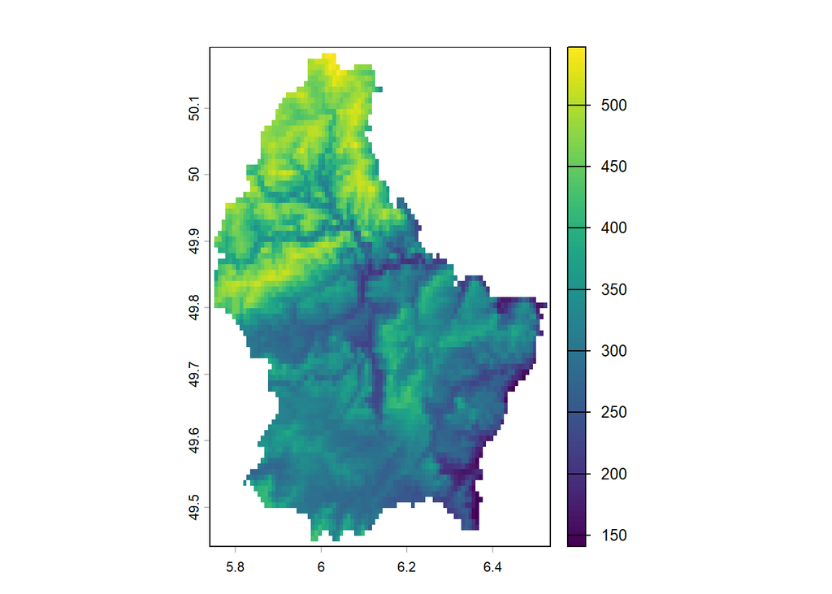

```r
plot(raster)
```

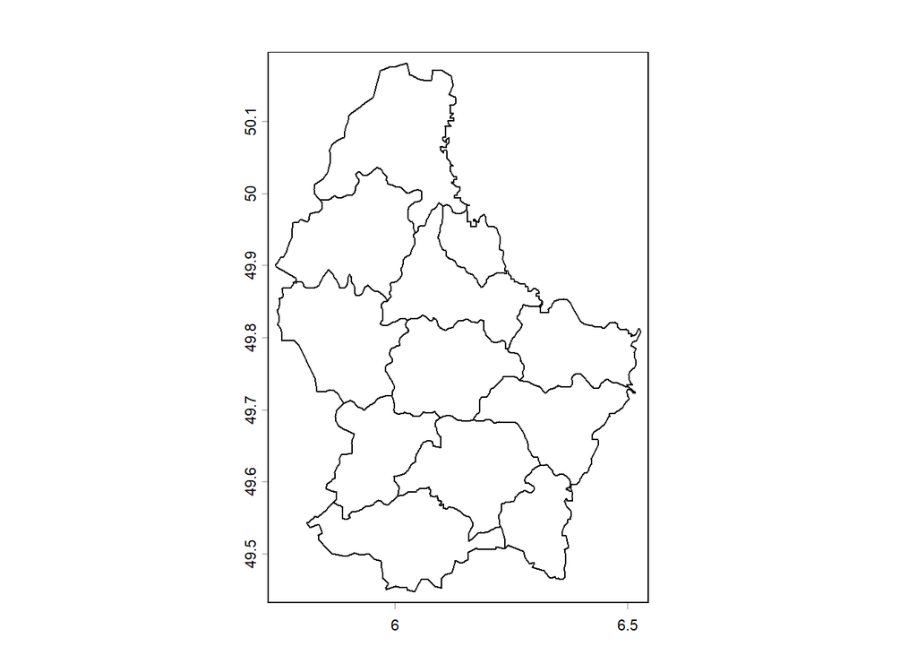

```r
# wyświetla tylko geometrie
# jeśli nie zdefiniowano żadnego atrybutu
plot(wektor)
```

Warstwy można na siebie nakładać używając argumentu `add = TRUE`. Pamiętaj żeby przed wyświetleniem sprawdzić czy warstwy mają jednakowe układy współrzędnych.

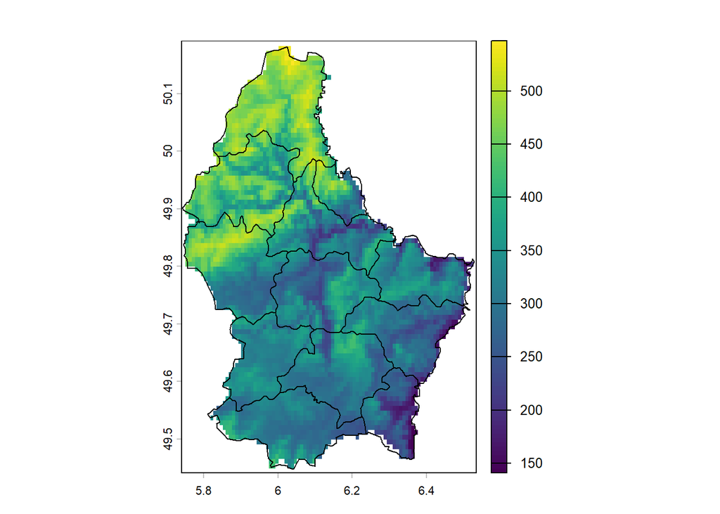

```r
plot(raster)
plot(wektor, add = TRUE)
```

Parametry wizualizacji oczywiście można dostosować. Sprawdź ich wykaz w dokumentacji funkcji (`?terra::plot`). Dla przykładu możemy nadać kolory na podstawie atrybutu `NAME_1` (gmina) używając argumentu `col` i definiując wybrane kolory. Oprócz tego, możemy zmienić kolor tła (argument `background`) oraz granic poligonów (argument `border`). Możemy również nadać rycinie tytuł używając argumentu `main`. Alternatywnie, zamiast nazw kolorów, można wykorzystać kod szesnastkowy, np. `#ffff00` będzie reprezentował odcień żółtego.

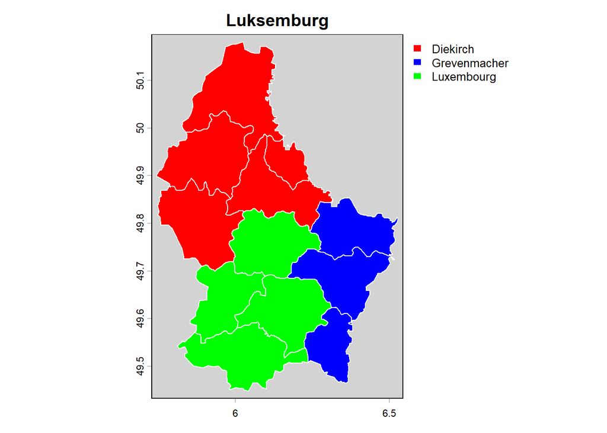

```r
plot(wektor, "NAME_1", col = c("red", "blue", "green"), background = "lightgrey",
     border = "white" , main = "Luksemburg")
```

Do bardziej zaawansowanych wizualizacji możesz wykorzystać na przykład pakiety [tmap](https://r-tmap.github.io/tmap/) czy [ggplot2](https://ggplot2.tidyverse.org/).

# Przetwarzanie

## Dane rastrowe

### Generowanie danych

W poprzedniej sekcji wykorzystaliśmy funkcję `rast()` do wczytania danych rastrowych, niemniej posiada ona więcej zastosowań. Na przykład można użyć ją do konwersji (macierz -> raster) czy wygenerowania nowego rastra z zadanymi parametrami. W przypadku tworzenia nowego rastra można zdefiniować m. in. liczbę wierszy, kolumn i warstw, zakres przestrzennych, układ współrzędnych czy rozdzielczość. Zdefiniujmy “szablon” bez wartości:

```r
raster = rast(nrows = 10, ncols = 20, nlyrs = 1,
              xmin = -180, xmax = 180, ymin = -90, ymax = 90,
              crs = "EPSG:4326")
raster
```

```
class       : SpatRaster
size        : 10, 20, 1  (nrow, ncol, nlyr)
resolution  : 18, 18  (x, y)
extent      : -180, 180, -90, 90  (xmin, xmax, ymin, ymax)
coord. ref. : lon/lat WGS 84 (EPSG:4326)
```

Funkcja `rast()` przyjmuje argument `vals`, który zostawiliśmy pusty, w związku z czym stworzonemu rastrowi nie zostały przypisane żadne wartości. Możemy to potwierdzić za pomocą funkcji `hasValues()`.

```r
hasValues(raster)
```

```
[1] FALSE
```

De facto, oznacza to, że stworzyliśmy jedynie metadane rastra (tj. “szablon”). Jeśli chcemy go wypełnić, to musimy przypisać / wygenerować tyle wartości z ilu komórek składa się raster.

```r
n = ncell(raster) # liczba komórek rastra
wartosci = rnorm(n, mean = 0, sd = 1) # wylosuj wartości z rozkładu normalnego
head(wartosci) # wyświetl 6 pierwszych wylosowanych wartości
```

```
[1]  0.2674470 -1.3019056  1.2468497  1.4178560 -0.3166841 -0.9159737
```

```r
# hist(wartosci) # histogram
```

Teraz przypiszmy wygenerowane wartości do `raster` za pomocą funkcji `values()`.

```r
values(raster) = wartosci
raster
```

```
class       : SpatRaster
size        : 10, 20, 1  (nrow, ncol, nlyr)
resolution  : 18, 18  (x, y)
extent      : -180, 180, -90, 90  (xmin, xmax, ymin, ymax)
coord. ref. : lon/lat WGS 84 (EPSG:4326)
source(s)   : memory
name        :     lyr.1
min value   : -3.794254
max value   :  2.549581
```

Wyświetlmy obiekt `raster`. Dodatkowo możemy wyświetlić wartości komórek jako etykiety używając funkcji `text()` z argumentami określającymi liczbę znaków (`digits`) oraz rozmiar tekstu (`cex`).

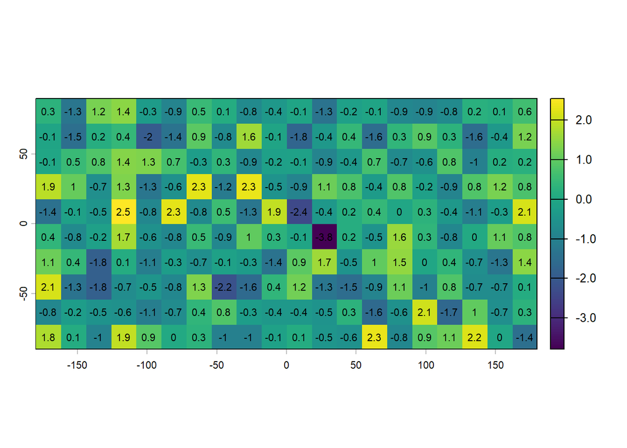

```r
plot(raster)
text(raster, digits = 1, cex = 0.7)
```

### Algebra rastrów

Na rastrach można wykonywać standardowe działania algebraiczne, operacje logiczne oraz funkcje matematyczne.

```r
r1 = sqrt(raster + 10)
r1
```

```
class       : SpatRaster
size        : 10, 20, 1  (nrow, ncol, nlyr)
resolution  : 18, 18  (x, y)
extent      : -180, 180, -90, 90  (xmin, xmax, ymin, ymax)
coord. ref. : lon/lat WGS 84 (EPSG:4326)
source(s)   : memory
name        :    lyr.1
min value   : 2.491134
max value   : 3.542539
```

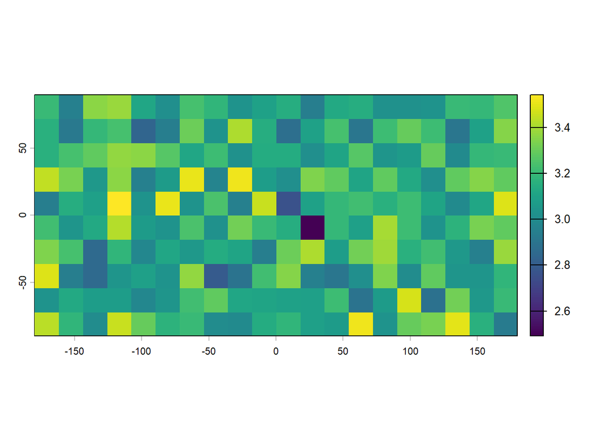

```r
plot(r1)
```

```r
r2 = abs(raster - r1)
r2
```

```
class       : SpatRaster
size        : 10, 20, 1  (nrow, ncol, nlyr)
resolution  : 18, 18  (x, y)
extent      : -180, 180, -90, 90  (xmin, xmax, ymin, ymax)
coord. ref. : lon/lat WGS 84 (EPSG:4326)
source(s)   : memory
name        :     lyr.1
min value   : 0.9929581
max value   : 6.2853871
```

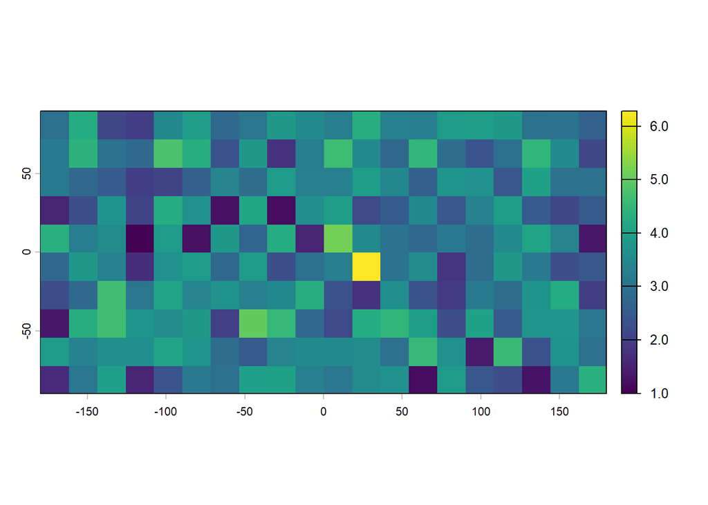

```r
plot(r2)
```

```r
r3 = raster < 0 # operacja logiczna
r3
```

```
class       : SpatRaster
size        : 10, 20, 1  (nrow, ncol, nlyr)
resolution  : 18, 18  (x, y)
extent      : -180, 180, -90, 90  (xmin, xmax, ymin, ymax)
coord. ref. : lon/lat WGS 84 (EPSG:4326)
source(s)   : memory
name        : lyr.1
min value   : FALSE
max value   :  TRUE
```

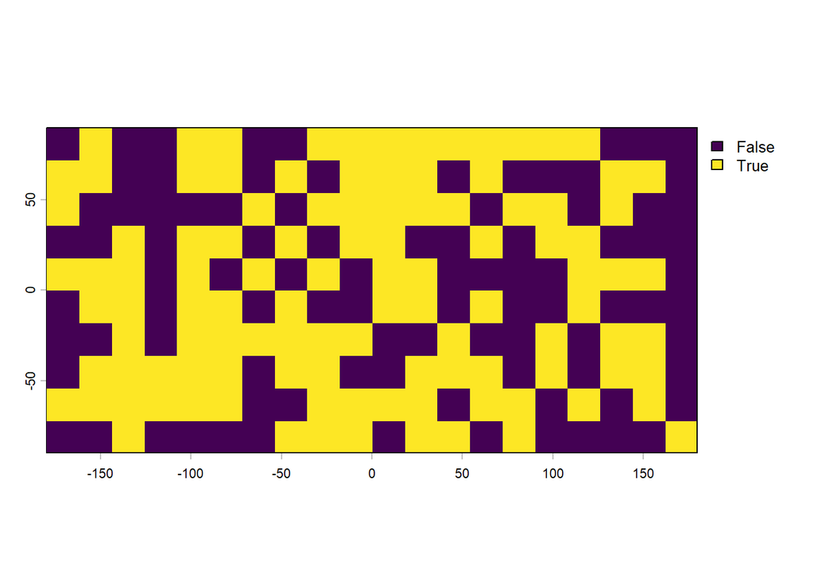

```r
plot(r3)
```

### Docinanie

Nadmierny zasięg rastra wykraczający poza obszar analizy można dociąć za pomocą funkcji `crop()` używając innego rastra (*SpatRaster*), wektora (*SpatVector*) lub zasięgu zdefiniowanego przy użyciu współrzędnych (*SpatExtent*). W poniższym przykładzie wyznaczymy zasięg używając funkcji `ext()`.

```r
zasieg = ext(-100, 100, -50, 50) # xmin, xmax, ymin, ymax
r = crop(raster, zasieg)
r
```

```
class       : SpatRaster
size        : 6, 12, 1  (nrow, ncol, nlyr)
resolution  : 18, 18  (x, y)
extent      : -108, 108, -54, 54  (xmin, xmax, ymin, ymax)
coord. ref. : lon/lat WGS 84 (EPSG:4326)
source(s)   : memory
name        :     lyr.1
min value   : -3.794254
max value   :  2.348110
```

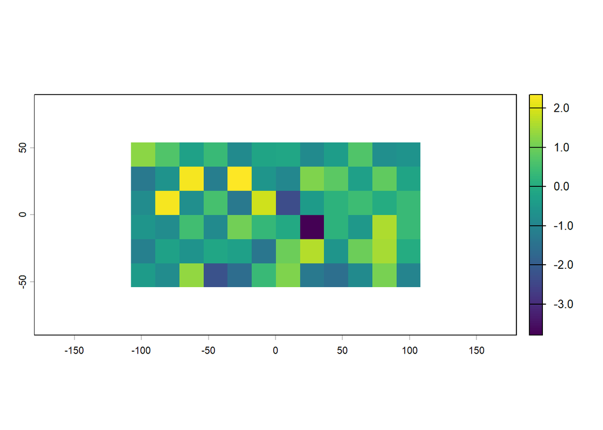

```r
plot(r, ext = ext(raster)) # porównaj z oryginalnym zasięgiem
```

Należy zauważyć, że zasięg dociętego rastra może różnić się od oczekiwanego, ponieważ zwracane są pełne komórki w wierszach i kolumnach.

### Zmiana rozdzielczości

Rozdzielczość przestrzenną rastra można zmienić za pomocą trzech funkcji:

- `disagg()` (zwiększa rozdzielczość, czyli komórki stają się mniejsze),
- `aggregate()` (zmniejsza rozdzielczość, czyli komórki stają się większe),
- `resample()` (przepróbkowanie do zdefiniowanej siatki).

Pierwsze dwie funkcje wymagają podanie współczynnika agregacji, natomiast ostatnia wymieniona funkcja wymaga wskazania rastra z oczekiwaną geometrią. W przypadku funkcji `disagg()` dostępne są dwie metody, tj. interpolacji najbliższego sąsiada (`near`) oraz dwuliniowej (`bilinear`). Ta pierwsza stosowana jest najczęściej w przypadku danych kategorycznych. Zauważ również, że zastosowanie tej metody powoduje podział komórki na mniejsze części, co nie wpływa na efekt wizualizacji.

```r
r1 = disagg(raster, fact = 2, method = "bilinear")
r2 = aggregate(raster, fact = 2, fun = "mean")
```

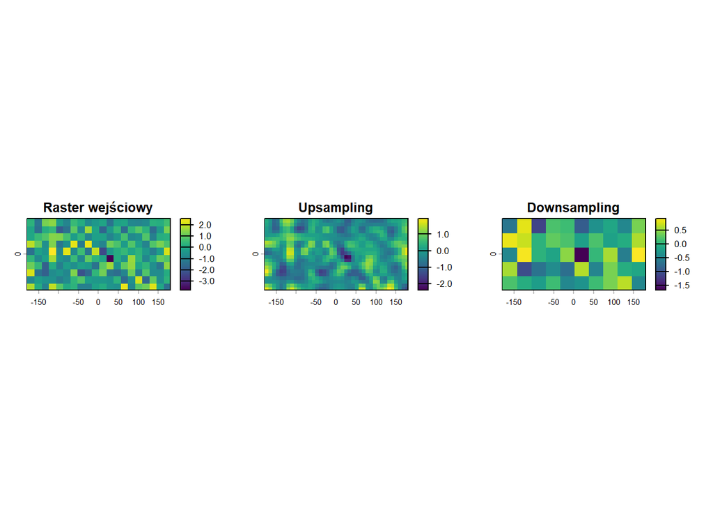

```r
par(mfrow = c(1, 3)) # wyświetl 3 rastry obok siebie
plot(raster, main = "Raster wejściowy")
plot(r1, main = "Upsampling")
plot(r2, main = "Downsampling")
```

Rozdzielczość rastrów można także sprawdzić za pomocą funkcji `res()`. Sprawdźmy jeszcze jak zastosować funkcję `resample()` w praktyce.

```r
szablon = rast(nrows = 20, ncols = 40,
               xmin = -180, xmax = 180, ymin = -90, ymax = 90)
r3 = resample(raster, szablon, method = "bilinear")
```

### Reprojekcja

Do transformacji przestrzennego układu współrzędnych służy funkcja `project()`. Tak jak w przypadku poprzednich funkcji można wykorzystać różne metody interpolacji. Przetransformujmy nasz aktualny układ `EPSG:4326` wyrażony w stopniach do odwzorowania Mollweidego (`+proj=moll`) wyrażonego w metrach.

```r
r_moll = project(raster, "+proj=moll", method = "bilinear")
r_moll
```

```
class       : SpatRaster
size        : 22, 45, 1  (nrow, ncol, nlyr)
resolution  : 788849.2, 806777.6  (x, y)
extent      : -18040096, 17458119, -8729059, 9020048  (xmin, xmax, ymin, ymax)
coord. ref. : +proj=moll +lon_0=0 +x_0=0 +y_0=0 +datum=WGS84 +units=m +no_defs
source(s)   : memory
name        :     lyr.1
min value   : -3.338541
max value   :  2.022000
```

Porównajmy otrzymany raster z oryginalnym.

```r
raster
```

```
class       : SpatRaster
size        : 10, 20, 1  (nrow, ncol, nlyr)
resolution  : 18, 18  (x, y)
extent      : -180, 180, -90, 90  (xmin, xmax, ymin, ymax)
coord. ref. : lon/lat WGS 84 (EPSG:4326)
source(s)   : memory
name        :     lyr.1
min value   : -3.794254
max value   :  2.549581
```

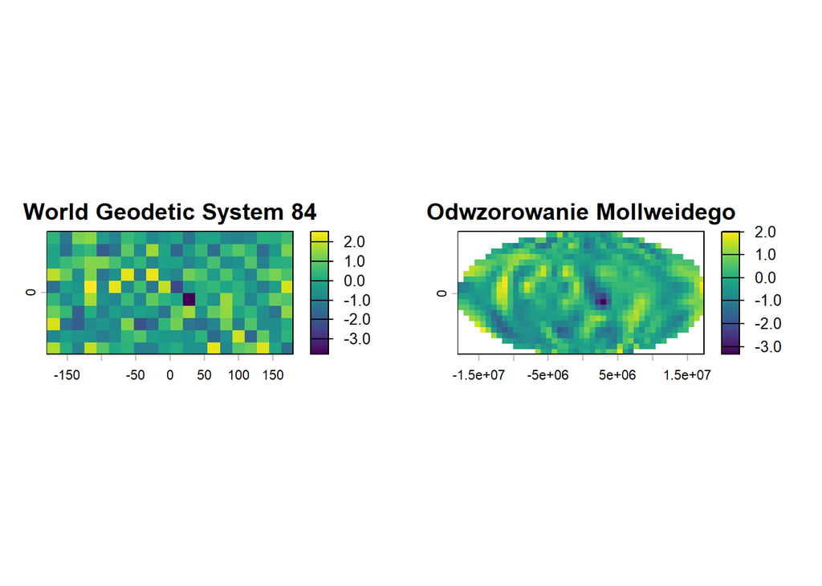

```r
par(mfrow = c(1, 2))
plot(raster, main = "World Geodetic System 84")
plot(r_moll, main = "Odwzorowanie Mollweidego")
```

Jeśli posiadasz dane rastrowe i wektorowe w różnych układach współrzędnych, to zalecana jest reprojekcja danych wektorowych z dwóch powodów:

- jest szybsza,
- jest odwracalna (transformacja odbywa się bez utraty precyzji).

### Statystyki globalne

Wyliczenie statystyk komórek warstwy rastrowej można wykonać za pomocą funkcji `global()`. Dla przykładu:

```r
# data.frame() łączy poniższe obiekty do jednego
data.frame(
  global(raster, "sum"),
  global(raster, "mean"),
  global(raster, "sd")
)
```

```
            sum        mean       sd
lyr.1 -7.313281 -0.03656641 1.066392
```

### Statystyki strefowe

Jeśli posiadamy dwa rastry, tj. pierwszy numeryczny, a drugi kategoryczny (określający strefy), to możemy wyliczyć statystyki strefowe. Najpierw wykorzystajmy funkcje `sample()` do wygenerowania kategorii oznaczonych numerami od 1 do 3 (w rzeczywistej analizie mogą one reprezentować, np. zbiornik wodny, las i strefę zabudowaną). Musimy ustawić argument `replace = TRUE`, aby wykonać losowanie ze zwracaniem.

```r
kategorie = sample(1:3, size = ncell(raster), replace = TRUE)
head(kategorie)
```

```
[1] 1 1 2 2 2 2
```

Następnie kopiujemy raster wejściowy `raster` wykorzystując funkcję `rast()` zastępując przy tym jego wartości `vals = kategorie` i nowy raster nazywamy `strefy`.

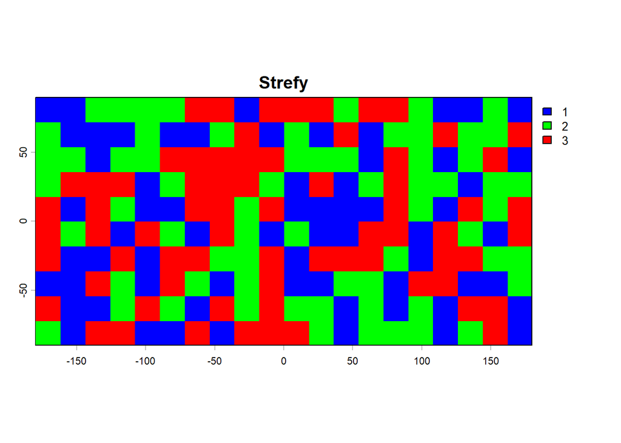

```r
strefy = rast(raster, vals = kategorie)
plot(strefy, main = "Strefy", col = c("blue", "green", "red"))
```

Teraz możemy obliczyć statystyki strefowe.

```r
stat_strefy = zonal(raster, strefy, fun = "mean")
stat_strefy
```

```
  lyr.1     lyr.1.1
1     1 -0.17590244
2     2 -0.01963149
3     3  0.07709178
```

### Reklasyfikacja

Reklasyfikacja wartości rastra możliwa jest za pomocą funkcji `classify()`. Załóżmy, że chcemy wszystkie wartości poniżej 0 zamienić na brakujące wartości (`NA`), a wszystkie wartości powyżej 0 zamienić na 10. W tym celu musimy stworzyć tabelę klasyfikacyjną składającą się z trzech kolumn:

1. dolny przedział wartości,
2. górny przedział wartości,
3. nowa wartość.

Tabelę najprościej stworzyć definiując uprzednio wektor i następnie transformując go do macierzy.

```r
# wektor
tabela = c(
  -Inf, 0, NA,
  0, Inf, 10
)
# zamiana wektora na macierz
tabela = matrix(tabela, ncol = 3, byrow = TRUE)
tabela
```

```
     [,1] [,2] [,3]
[1,] -Inf    0   NA
[2,]    0  Inf   10
```

Teraz przeprowadźmy reklasyfikację.

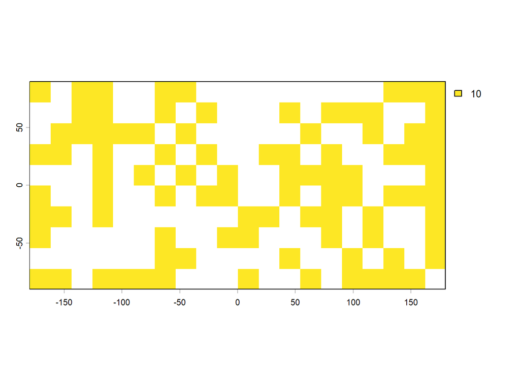

```r
reklasyfikacja = classify(raster, tabela)
plot(reklasyfikacja)
```

Istnieje również prostsza alternatywa w postaci `subst()` ukierunkowana na zastępowanie wartości.

### Okno ruchome

Ostatnią omawianą funkcją jest `focal()` służącą do obliczania wartości na podstawie sąsiadujących komórek rastra w ruchomym oknie. Można zdefiniować dowolny kształt sąsiedztwa (np. prostokąt, koło) oraz nadać komórkom odpowiednie wagi. Zazwyczaj niniejszą funkcję wykorzystuje się do wygładzania danych numerycznych za pomocą średniej czy mediany oraz danych kategorycznych za pomocą mody.

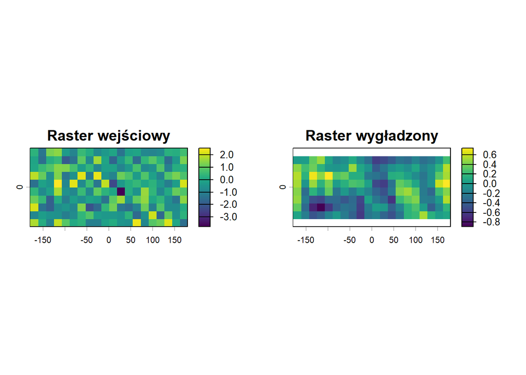

```r
r = focal(raster, w = 3, fun = "mean")
par(mfrow = c(1, 2))
plot(raster, main = "Raster wejściowy")
plot(r, main = "Raster wygładzony")
```

Omówiliśmy tylko podstawowe i najczęściej stosowane funkcje do przetwarzania danych rastrowych. Pakiet **terra** oferuje ich zdecydowanie więcej (sprawdź dokumentację).

## Dane wektorowe

Wczytajmy dane wektorowe Luksemburgu wykorzystane na pierwszych zajęciach.

```r
sciezka = system.file("ex/lux.shp", package = "terra")
wektor = vect(sciezka)
wektor
```

```
 class       : SpatVector
 geometry    : polygons
 dimensions  : 12, 6  (geometries, attributes)
 extent      : 5.74414, 6.528252, 49.44781, 50.18162  (xmin, xmax, ymin, ymax)
 source      : lux.shp
 coord. ref. : lon/lat WGS 84 (EPSG:4326)
 names       :  ID_1   NAME_1  ID_2   NAME_2  AREA       POP
 type        : <num>    <chr> <num>    <chr> <num>     <num>
 values      :     1 Diekirch     1 Clervaux   312 1.808e+04
                   1 Diekirch     2 Diekirch   218 3.254e+04
                   1 Diekirch     3  Redange   259 1.866e+04
```

Warto zauważyć, że funkcja `vect()` poza standardowym odczytem oferuje więcej zaawansowanych możliwości:

- wczytanie określonego zakresu przestrzennego,
- wczytanie określonych warstw,
- wczytanie określonego rodzaju danych (geometrie lub atrybuty),
- tworzenie zapytań bazodanowych (SQL),
- stworzenie wskaźnika do pliku (*proxy*).

Zasadniczo, do atrybutów warstwy wektorowej możemy odwołać się na dwa sposoby używając:

- znaku dolara `$` – zwraca wektor bez geometrii,
- nawiasu kwadratowego `[]` – zwraca geometrię z wybranymi atrybutami.

```r
wektor$NAME_2
```

```
 [1] "Clervaux"         "Diekirch"         "Redange"          "Vianden"
 [5] "Wiltz"            "Echternach"       "Remich"           "Grevenmacher"
 [9] "Capellen"         "Esch-sur-Alzette" "Luxembourg"       "Mersch"
```

```r
wektor[, "NAME_2"]
```

```
 class       : SpatVector
 geometry    : polygons
 dimensions  : 12, 1  (geometries, attributes)
 extent      : 5.74414, 6.528252, 49.44781, 50.18162  (xmin, xmax, ymin, ymax)
 source      : lux.shp
 coord. ref. : lon/lat WGS 84 (EPSG:4326)
 names       :   NAME_2
 type        :    <chr>
 values      : Clervaux
               Diekirch
                Redange
```

Oprócz tego, możemy pozyskać wszystkie atrybuty w postaci ramki danych używając funkcji `as.data.frame()`.

### Obliczanie powierzchni

W celu obliczenia powierzchni poligonów należy zastosować funkcję `expanse()`. Ta funkcja automatycznie wykonuje obliczenia dla układów wyrażonych w stopniach, więc nie jest wymagana projekcja do planarnego układu współrzędnych. Można również określić jednostki, w których zwrócone będą wyniki przy pomocy argumentu `unit`.

```r
powierzchnia = expanse(wektor, unit = "km")
data.frame(nazwa = wektor$NAME_2, powierzchnia)
```

```
              nazwa powierzchnia
1          Clervaux    312.28321
2          Diekirch    218.67403
3           Redange    259.45481
4           Vianden     76.20041
5             Wiltz    263.17426
6        Echternach    188.28214
7            Remich    128.99150
8      Grevenmacher    210.35449
9          Capellen    185.63077
10 Esch-sur-Alzette    251.32202
11       Luxembourg    237.11300
12           Mersch    233.32996
```

### Generowanie punktów

Można wygenerować punkty o rozkładzie regularnym (`method = "regular"`) lub losowych (`method = "random"`) na podstawie wejściowej geometrii używając funkcji `spatSample()`. Istnieje również możliwość próbkowania stratyfikowanego (wtedy dla każdego poligonu zostanie wygenerowanych $n$ punktów).

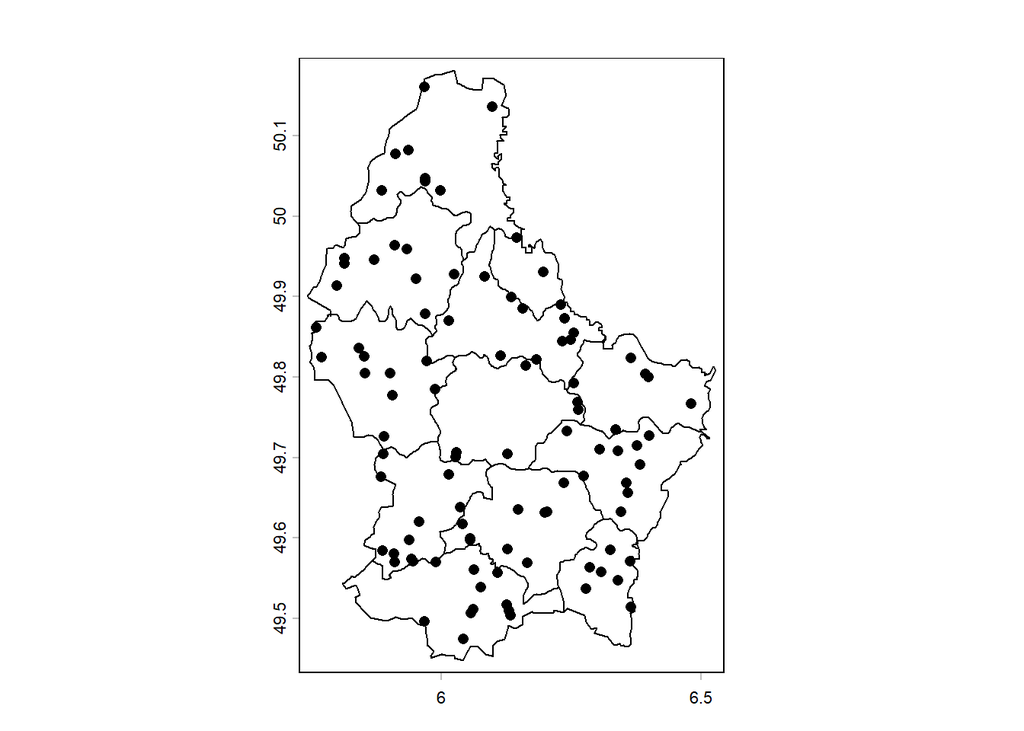

```r
proba = spatSample(wektor, size = 100, method = "random")
plot(wektor)
plot(proba, add = TRUE)
```

### Otoczka wypukła

Otoczka wypukła jest najmniejszym wielokątem wypukłym ograniczającym dany zbiór punktów. Innymi słowy, jest to wielokąt, którego wierzchołki stanowią najbardziej zewnętrzne punkty zbioru. Do jej wygenerowania służy funkcja `convHull()`.

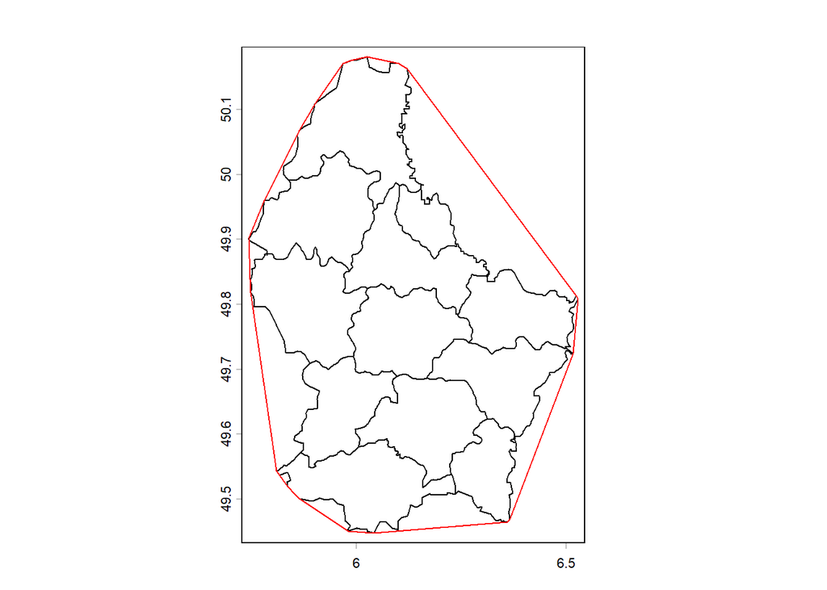

```r
otoczka = convHull(wektor)
plot(wektor)
plot(otoczka, add = TRUE, border = "red")
```

### Bufory

Bufory można wygenerować wykorzystując funkcje `buffer()`. Bufory obliczane są dla każdej geometrii osobno, w związku z czym, jeśli chcemy stworzyć jeden bufor musimy zastosować funkcję agregującą geometrie, tj. `aggregate()`; łączy ona wiele geometrii w jedną. Funkcja `buffer()` wymaga wskazania odległości bufora (argument `width`) i należy odnotować, że:

- domyślną jednostką długości dla układu geograficznego są metry (nie stopnie),
- argument `width` jest zwektoryzowany, zatem można określić różne odległości dla kolejnych geometrii.

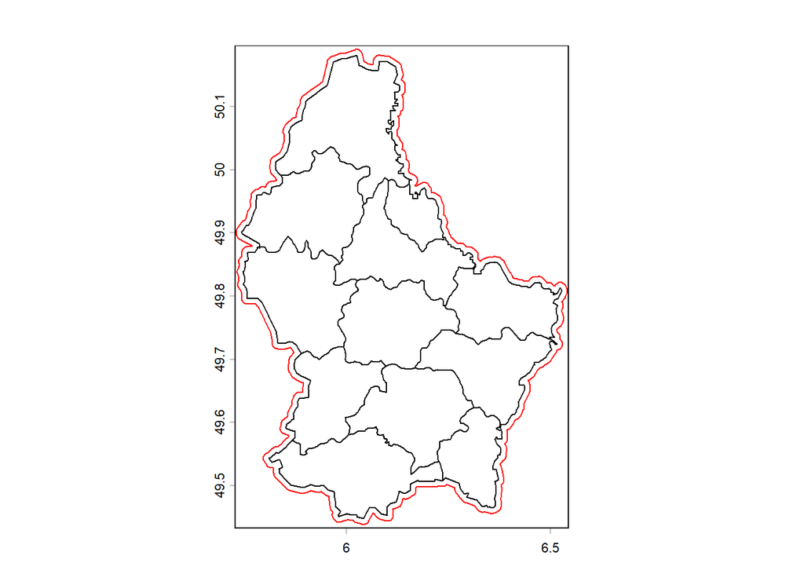

```r
bufor = buffer(aggregate(wektor), width = 1000)
plot(wektor)
plot(bufor, add = TRUE, border = "red")
```

### Centroidy

Centroid jest to punkt określający geometryczny środek wielokąta. Dla wielokątów wypukłych (tj. kąty takiej figury są mniejsze niż 180°) wyliczany jest na podstawie średniej arytmetycznej współrzędnych wierzchołków. Jego wyznaczenie jest możliwe używając funkcji `centroids()`. W przypadku wielokątów wklęsłych centroid może znajdować się poza obiektem, wtedy może zastosować argument `inside = TRUE`, który wymusi przybliżoną lokalizację wewnątrz obiektu.

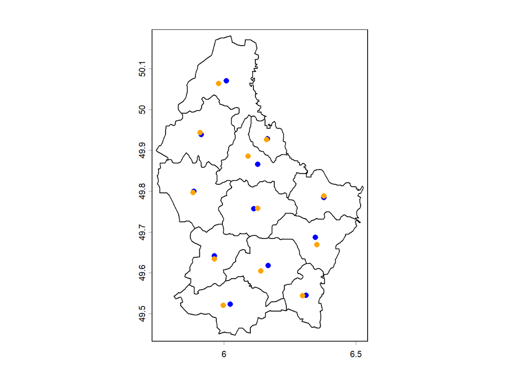

```r
centroidy = centroids(wektor, inside = FALSE)
centroidy_wewnatrz = centroids(wektor, inside = TRUE)
plot(wektor)
plot(centroidy, add = TRUE, col = "blue")
plot(centroidy_wewnatrz, add = TRUE, col = "orange")
```

### Obliczanie odległości

W kolejnym kroku możemy obliczyć jak oddalone są centroidy od siebie używając funkcję `distance()`. Wymieniona funkcja również automatycznie wykonuje obliczenia dla układów geograficznych (jednostki w stopniach) i wynik domyślnie zwracany jest w metrach. Jeśli podamy jeden argument w funkcji, to zostaną wyliczone odległości każdego obiektu z każdym.

```r
odleglosci = distance(centroidy)
```

Jako wynik otrzymujemy obiekt klasy `dist`, który reprezentuje jako wektor dolną połowę macierzy odległości. Wykorzystując funkcję `as.matrix()` możemy przetransformować ten obiekt do pełnej macierzy.

```r
macierz_odleglosci = as.matrix(odleglosci)
macierz_odleglosci[1:5, 1:5]
```

```
         1         2        3         4        5
1     0.00 24290.360 31366.47 19330.917 16147.66
2 24290.36     0.000 18794.53  7486.065 17280.29
3 31366.47 18794.533     0.00 24595.137 15579.42
4 19330.92  7486.065 24595.14     0.000 17986.54
5 16147.66 17280.292 15579.42 17986.538     0.00
```

Dla ułatwienia możemy również kolumnom i wierszom nadać nazwy jednostek administracyjnych.

```r
colnames(macierz_odleglosci) = rownames(macierz_odleglosci) = centroidy$NAME_2
# View(macierz_odleglosci) # wyświetl
```

### Relacje przestrzenne

Do określenia [relacji przestrzennych](https://en.wikipedia.org/wiki/DE-9IM) między obiektami służy funkcja `relate()`. Dla przykładu możemy sprawdzić czy poligon zawiera (`relation = "contains"`) wylosowany punkt. Jako wynik funkcji zwracana jest macierz z wartościami logicznymi.

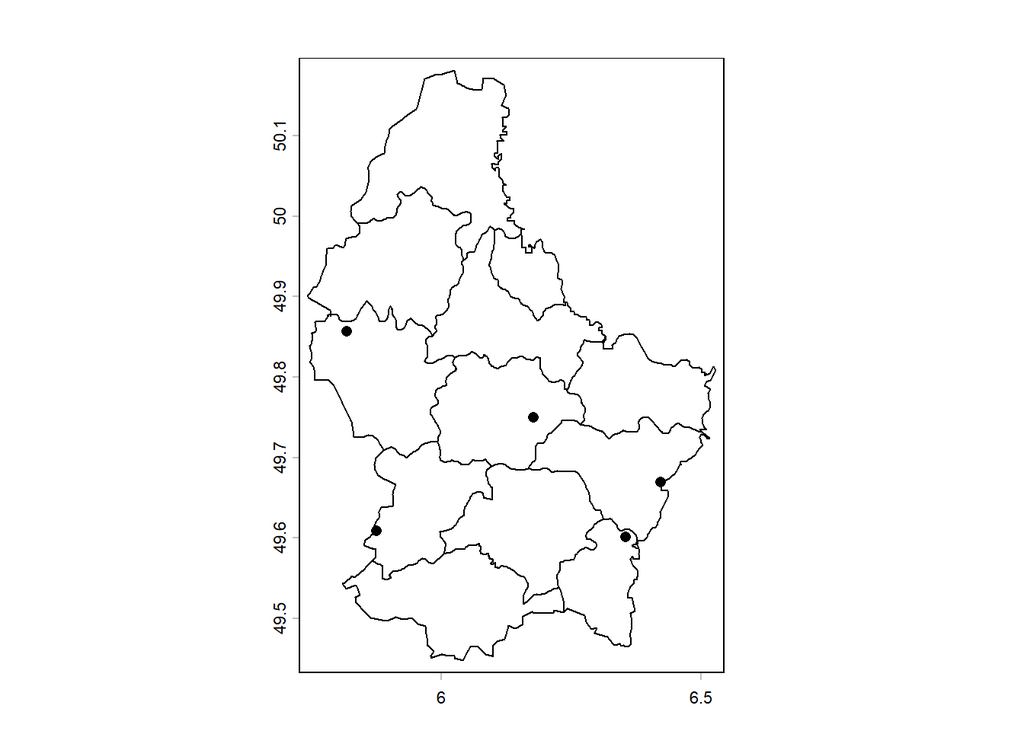

```r
proba = spatSample(wektor, size = 5, method = "random")
plot(wektor)
plot(proba, add = TRUE)
```

```r
relate(wektor, proba, relation = "contains")
```

```
       [,1]  [,2]  [,3]  [,4]  [,5]
 [1,] FALSE FALSE FALSE FALSE FALSE
 [2,] FALSE FALSE FALSE FALSE FALSE
 [3,] FALSE FALSE FALSE FALSE  TRUE
 [4,] FALSE FALSE FALSE FALSE FALSE
 [5,] FALSE FALSE FALSE FALSE FALSE
 [6,] FALSE FALSE FALSE FALSE FALSE
 [7,] FALSE  TRUE FALSE FALSE FALSE
 [8,]  TRUE FALSE FALSE FALSE FALSE
 [9,] FALSE FALSE  TRUE FALSE FALSE
[10,] FALSE FALSE FALSE FALSE FALSE
[11,] FALSE FALSE FALSE FALSE FALSE
[12,] FALSE FALSE FALSE  TRUE FALSE
```

W wierszach zawarte są jednostki administracyjne, natomiast w kolumnach wylosowane punkty.

### Docinanie

Podobnie jak w przypadku danych rastrowych, możemy zmniejszyć zasięg warstwy wektorowej używając funkcję `crop()`.

```r
zasieg = ext(c(5.9, 6.3, 49.6, 49.9))
wektor_dociety = crop(wektor, zasieg)
```

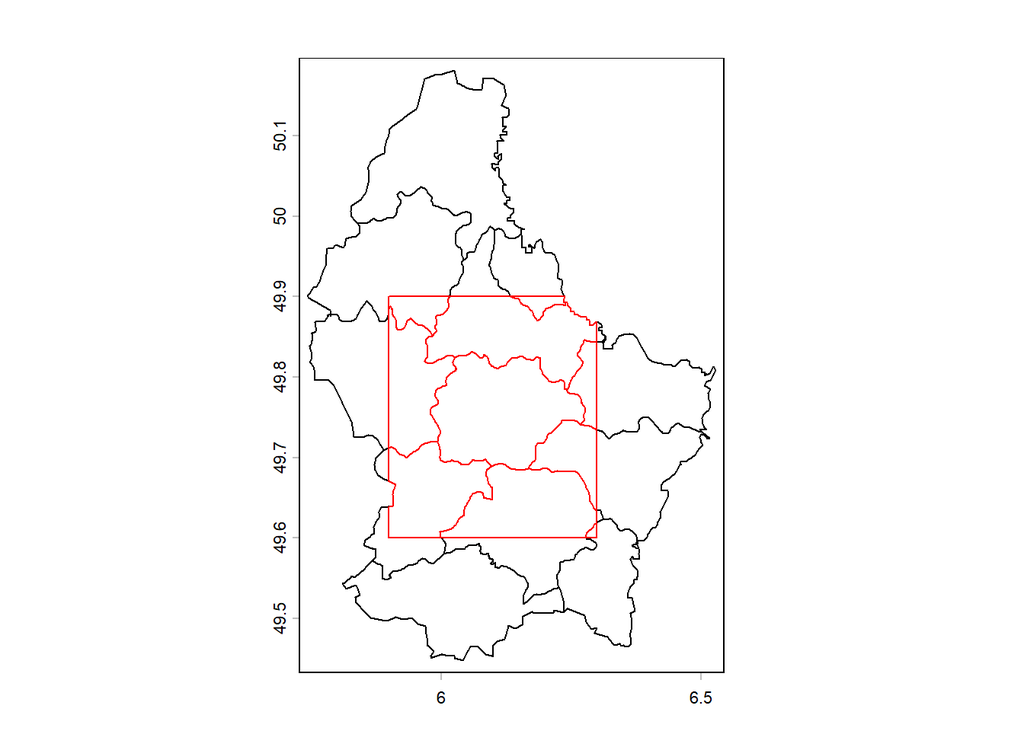

```r
plot(wektor)
plot(wektor_dociety, add = TRUE, border = "red")
```

Alternatywnie docięcie można wykonać używając funkcji `intersect()`.

### Reprojekcja

Reprojekcja danych wektorowych wygląda identycznie tak jak w przypadku danych rastrowych.

```r
wektor_3857 = project(wektor, "EPSG:3857")
```

Oczywiście w tej sekcji zostały zaprezentowane jedynie wybrane funkcje do przetwarzania danych wektorowych.

# Zadania

1. Wczytaj plik `logo.tif` z pakietu i sprawdź jego metadane.
2. Pobierz dowolnie wybrane przez siebie dane z [Natural Earth](https://www.naturalearthdata.com/downloads/) i przygotuj wizualizację. Funkcje `download.file()` oraz `unzip()` mogą być przydatne w tym celu.
3. Z portalu [OpenTopography](https://opentopography.org/) pobierz numeryczny model pokrycia terenu (np. NASADEM lub SRTM) dla małego fragmentu Polski i wykonaj następujące czynności:
- sprawdź metadane pobranego rastra i wyświetl go,
- transformuj układ współrzędnych do `EPSG:2180`,
- przytnij raster do zmniejszonego zasięgu przestrzennego,
- wygładź wartości używając średniej arytmetycznej w oknie ruchomym,
- oblicz statystyki rastra, tj. wartość minimalna i maksymalna, średnia oraz odchylenie standardowe,
- zapisz raster na dysku z kompresją LZW.
4. Pobierz granice powiatów (np. z Geoportalu), następnie wylicz ich centroidy i wskaż te powiaty, które są położone najbliżej i najdalej. Wskazówki: (1) Odległość obiektu od samego siebie wynosi 0 m i trzeba to wykluczyć. (2) Do znalezienia indeksu o minimalnej lub maksymalnej wartości można wykorzystać funkcje `which()` z argumentem `arr.ind = TRUE`. Zastanów się również jak na wyniki analizy wpływają miasta na prawach powiatu oraz [eksklawy powiatów](https://pl.wikipedia.org/wiki/Eksklawa#Powiaty).
5. W katalogu `dane` znajdziesz 9 warstw rastrowych. Sprawdź ich metadane. Jeśli wszystkie parametry rastrów są identyczne, to połącz warstwy reprezentujące zmienne ilościowe w jeden raster wielokanałowy i zapisz go na dysku.